# GLM_GAM_paty

Patricia Wellhöfer

12/31/2021

```r
library(magrittr)
library(data.table)
library(dplyr)
library(lubridate)
library(caret)
library(inspectdf)
library(ggplot2)
library(GGally)
library(mgcv)
library(splitTools)
library(performance)
library(knitr)
opts_chunk$set(fig.align="center", echo=TRUE)

knit_hooks$set(inline=function(x) {
  prettyNum(x, big.mark=",")
})
```

# Research Question

# Data Import and Cleaning

```r
df.ar <- fread("data/application_record.csv", stringsAsFactors = TRUE)
df.cr <- fread("data/credit_record.csv", stringsAsFactors = TRUE)
```

## View Data

### Application Record Dataframe

DAYS_BIRTH and DAYS_EMPLOYED columns count backwards from “current” day (0), -1 means yesterday, etc.  
DAYS_EMPLOYED is positive, if the person is currently unemployed.

|  | type |
| --- | --- |
| ID | integer |
| CODE_GENDER | factor |
| FLAG_OWN_CAR | factor |
| FLAG_OWN_REALTY | factor |
| CNT_CHILDREN | integer |
| AMT_INCOME_TOTAL | numeric |
| NAME_INCOME_TYPE | factor |
| NAME_EDUCATION_TYPE | factor |
| NAME_FAMILY_STATUS | factor |
| NAME_HOUSING_TYPE | factor |
| DAYS_BIRTH | integer |
| DAYS_EMPLOYED | integer |
| FLAG_MOBIL | integer |
| FLAG_WORK_PHONE | integer |
| FLAG_PHONE | integer |
| FLAG_EMAIL | integer |
| OCCUPATION_TYPE | factor |
| CNT_FAM_MEMBERS | numeric |

| ID | CODE_GENDER | FLAG_OWN_CAR | FLAG_OWN_REALTY | CNT_CHILDREN | AMT_INCOME_TOTAL | NAME_INCOME_TYPE | NAME_EDUCATION_TYPE | NAME_FAMILY_STATUS | NAME_HOUSING_TYPE | DAYS_BIRTH | DAYS_EMPLOYED | FLAG_MOBIL | FLAG_WORK_PHONE | FLAG_PHONE | FLAG_EMAIL | OCCUPATION_TYPE | CNT_FAM_MEMBERS |
| --- | --- | --- | --- | --- | --- | --- | --- | --- | --- | --- | --- | --- | --- | --- | --- | --- | --- |
| 5008804 | M | Y | Y | 0 | 427500 | Working | Higher education | Civil marriage | Rented apartment | -12005 | -4542 | 1 | 1 | 0 | 0 |  | 2 |
| 5008805 | M | Y | Y | 0 | 427500 | Working | Higher education | Civil marriage | Rented apartment | -12005 | -4542 | 1 | 1 | 0 | 0 |  | 2 |
| 5008806 | M | Y | Y | 0 | 112500 | Working | Secondary / secondary special | Married | House / apartment | -21474 | -1134 | 1 | 0 | 0 | 0 | Security staff | 2 |
| 5008808 | F | N | Y | 0 | 270000 | Commercial associate | Secondary / secondary special | Single / not married | House / apartment | -19110 | -3051 | 1 | 0 | 1 | 1 | Sales staff | 1 |
| 5008809 | F | N | Y | 0 | 270000 | Commercial associate | Secondary / secondary special | Single / not married | House / apartment | -19110 | -3051 | 1 | 0 | 1 | 1 | Sales staff | 1 |
| 5008810 | F | N | Y | 0 | 270000 | Commercial associate | Secondary / secondary special | Single / not married | House / apartment | -19110 | -3051 | 1 | 0 | 1 | 1 | Sales staff | 1 |

### Credit Record Dataframe

MONTHS_BALANCE column counts backward from “current” month (0), -1 = previous month, -2 = 2 months prior, etc.  
STATUS column: 0 = 1-29 days past due, 1 = 30-59 days past due, 2 = 60-89 days overdue, 3 = 90-119 days overdue, 4 = 120-149 days overdue, 5 = Overdue or bad debts, write-offs for more than 150 days, C = paid off that month, X = No loan for the month

|  | type |
| --- | --- |
| ID | integer |
| MONTHS_BALANCE | integer |
| STATUS | factor |

| ID | MONTHS_BALANCE | STATUS |
| --- | --- | --- |
| 5001711 | 0 | X |
| 5001711 | -1 | 0 |
| 5001711 | -2 | 0 |
| 5001711 | -3 | 0 |
| 5001712 | 0 | C |
| 5001712 | -1 | C |

## Clean Data

### Cleaning application_record.csv

Remove duplicate IDs from application_record.csv

```r
df.ar$ID %>% unique() %>% length()
## [1] 438510

duplicates <- df.ar %>% group_by(ID) %>% summarise(count = n()) %>% filter(count > 1)
df.ar.mod <- df.ar %>% filter(!ID %in% duplicates$ID)

df.ar.mod$ID %>% unique() %>% length()
## [1] 438463
```

### Cleaning credit_record.csv

The original dataset was made available on 2020-03-24, so it is presumed current month is March 2020. From months_balance we create 2 new columns indicating the month and year for each observation. Observations older than 2 years are removed.

```r
# Extract month and year from months_balance in df.cr
df.cr$month_balance <- format(as.Date("2020-03-24") %m+% months(df.cr$MONTHS_BALANCE), "%B")
df.cr$year_balance <- format(as.Date("2020-03-24") %m+% months(df.cr$MONTHS_BALANCE), "%Y") %>% as.integer(.)

# Remove records older than 2 years
df.cr.mod <- df.cr %>% filter(MONTHS_BALANCE > -24)

# Assign customer status
df.status <- df.cr.mod %>%
  group_by(ID) %>%
  summarise(cnt_status_good = length(STATUS[STATUS==0|STATUS==1|STATUS=='C']),
            cnt_status_bad = n() - cnt_status_good,
            percent_good = round(cnt_status_good / n() * 100),
            percent_bad = round(cnt_status_bad / n() * 100)) %>%
  mutate(
    customer_status_good = ifelse(percent_good >= 50, 1, 0)
  ) %>%
  select(ID, customer_status_good, percent_good)

df.status$customer_status_good <- as.factor(df.status$customer_status_good)
```

### Join datasets

The two cleaned datasets are joined and only records where IDs exist in both are kept.

```r
df.cc.raw <- inner_join(x = df.status, y = df.ar.mod, by = "ID") %>%
  mutate(ID = as.factor(ID),
         CNT_FAM_MEMBERS = as.integer(CNT_FAM_MEMBERS),
         age_years = as.numeric(round(DAYS_BIRTH * (-1) / 365.25), 0),         # instead of DAYS_BIRTH
         work_years = as.numeric(round((DAYS_EMPLOYED * (-1) / 365.25), 0)),   # instead of DAYS_EMPLOYED, negative: Pensioner
         FLAG_MOBIL = as.factor(FLAG_MOBIL),
         FLAG_WORK_PHONE = as.factor(FLAG_WORK_PHONE),
         FLAG_PHONE = as.factor(FLAG_PHONE),
         FLAG_EMAIL = as.factor(FLAG_EMAIL))

# Change column names to lower case
setnames(df.cc.raw, tolower(names(df.cc.raw)))

# Look at the factor levels
df.cc.raw %>%
  select(-id) %>%
  select_if(is.factor) %>%
  sapply(., FUN = levels)
```

```
## $customer_status_good
## [1] "0" "1"
##
## $code_gender
## [1] "F" "M"
##
## $flag_own_car
## [1] "N" "Y"
##
## $flag_own_realty
## [1] "N" "Y"
##
## $name_income_type
## [1] "Commercial associate" "Pensioner"            "State servant"
## [4] "Student"              "Working"
##
## $name_education_type
## [1] "Academic degree"               "Higher education"
## [3] "Incomplete higher"             "Lower secondary"
## [5] "Secondary / secondary special"
##
## $name_family_status
## [1] "Civil marriage"       "Married"              "Separated"
## [4] "Single / not married" "Widow"
##
## $name_housing_type
## [1] "Co-op apartment"     "House / apartment"   "Municipal apartment"
## [4] "Office apartment"    "Rented apartment"    "With parents"
##
## $flag_mobil
## [1] "1"
##
## $flag_work_phone
## [1] "0" "1"
##
## $flag_phone
## [1] "0" "1"
##
## $flag_email
## [1] "0" "1"
##
## $occupation_type
##  [1] ""                      "Accountants"           "Cleaning staff"
##  [4] "Cooking staff"         "Core staff"            "Drivers"
##  [7] "HR staff"              "High skill tech staff" "IT staff"
## [10] "Laborers"              "Low-skill Laborers"    "Managers"
## [13] "Medicine staff"        "Private service staff" "Realty agents"
## [16] "Sales staff"           "Secretaries"           "Security staff"
## [19] "Waiters/barmen staff"
```

```r
# flag_mobil = 1 for all IDs => exclude from final dataset

# occupation_type has "" level => replace with NA
levels(df.cc.raw$occupation_type)[levels(df.cc.raw$occupation_type)==""] <- "NA"
# df.cc.raw$occupation_type %>% table()                                        # check that "" are updated as NA

# Set order of levels in education type
df.cc.raw$name_education_type <- factor(df.cc.raw$name_education_type, levels=c("Lower secondary", "Secondary / secondary special", "Incomplete higher", "Higher education", "Academic degree"), ordered = TRUE)

# Convert -ve values to NA
df.cc.raw$work_years[df.cc.raw$work_years == '-1000'] <- NA

# Select columns
# months_balance, days_birth, days_employed and flag_mobil columns are excluded
df.cc <- df.cc.raw %>%
  select(id,
         code_gender,
         age_years,
         name_education_type,
         name_income_type,
         name_housing_type,
         name_family_status,
         cnt_children,
         cnt_fam_members,
         flag_own_car,
         flag_own_realty,
         work_years,
         amt_income_total,
         occupation_type,
         flag_work_phone,
         flag_phone,
         flag_email,
         customer_status_good,
         percent_good)
```

Remove additional duplicates. Even tough entries have different ID’s, all the other columns are the same. That’s why we only keep the unique ID’s, which also have uniqueness in all the other columns.

```r
df.cc <- df.cc[!duplicated(df.cc[c(2:17)]),]

# remove NA-values
df.cc <- na.omit(df.cc)
```

### Check Final Dataframe

```r
# Meta information from df.cc
nlevels(df.cc$id)
## [1] 32848

str(df.cc)
## tibble [7,839 x 19] (S3: tbl_df/tbl/data.frame)
##  $ id                  : Factor w/ 32848 levels "5008804","5008805",..: 1 3 4 11 12 18 21 24 25 27 ...
##  $ code_gender         : Factor w/ 2 levels "F","M": 2 2 1 2 2 1 1 1 2 2 ...
##  $ age_years           : num [1:7839] 33 59 52 46 49 29 27 30 35 32 ...
##  $ name_education_type : Ord.factor w/ 5 levels "Lower secondary"<..: 4 2 2 4 2 3 2 2 2 4 ...
##  $ name_income_type    : Factor w/ 5 levels "Commercial associate",..: 5 5 1 5 1 5 5 5 5 1 ...
##  $ name_housing_type   : Factor w/ 6 levels "Co-op apartment",..: 5 2 2 2 2 2 2 2 2 2 ...
##  $ name_family_status  : Factor w/ 5 levels "Civil marriage",..: 1 2 4 2 2 2 2 4 2 2 ...
##  $ cnt_children        : int [1:7839] 0 0 0 0 0 0 0 1 3 1 ...
##  $ cnt_fam_members     : int [1:7839] 2 2 1 2 2 2 2 2 5 3 ...
##  $ flag_own_car        : Factor w/ 2 levels "N","Y": 2 2 1 2 2 2 1 1 2 1 ...
##  $ flag_own_realty     : Factor w/ 2 levels "N","Y": 2 2 2 2 2 1 2 2 2 2 ...
##  $ work_years          : num [1:7839] 12 3 8 2 3 3 4 4 3 6 ...
##  $ amt_income_total    : num [1:7839] 427500 112500 270000 270000 135000 ...
##  $ occupation_type     : Factor w/ 19 levels "NA","Accountants",..: 1 18 16 2 10 2 10 1 10 12 ...
##  $ flag_work_phone     : Factor w/ 2 levels "0","1": 2 1 1 2 1 1 1 1 1 1 ...
##  $ flag_phone          : Factor w/ 2 levels "0","1": 1 1 2 2 1 1 2 1 1 1 ...
##  $ flag_email          : Factor w/ 2 levels "0","1": 1 1 2 2 1 1 1 1 1 1 ...
##  $ customer_status_good: Factor w/ 2 levels "0","1": 2 2 1 2 1 2 2 2 2 2 ...
##  $ percent_good        : num [1:7839] 94 50 40 100 0 100 100 100 100 93 ...
##  - attr(*, "na.action")= 'omit' Named int [1:1502] 4 8 18 26 36 42 58 60 64 76 ...
##   ..- attr(*, "names")= chr [1:1502] "4" "8" "18" "26" ...

head(df.cc) %>% kable()
```

| id | code_gender | age_years | name_education_type | name_income_type | name_housing_type | name_family_status | cnt_children | cnt_fam_members | flag_own_car | flag_own_realty | work_years | amt_income_total | occupation_type | flag_work_phone | flag_phone | flag_email | customer_status_good | percent_good |
| --- | --- | --- | --- | --- | --- | --- | --- | --- | --- | --- | --- | --- | --- | --- | --- | --- | --- | --- |
| 5008804 | M | 33 | Higher education | Working | Rented apartment | Civil marriage | 0 | 2 | Y | Y | 12 | 427500 | NA | 1 | 0 | 0 | 1 | 94 |
| 5008806 | M | 59 | Secondary / secondary special | Working | House / apartment | Married | 0 | 2 | Y | Y | 3 | 112500 | Security staff | 0 | 0 | 0 | 1 | 50 |
| 5008808 | F | 52 | Secondary / secondary special | Commercial associate | House / apartment | Single / not married | 0 | 1 | N | Y | 8 | 270000 | Sales staff | 0 | 1 | 1 | 0 | 40 |
| 5008815 | M | 46 | Higher education | Working | House / apartment | Married | 0 | 2 | Y | Y | 2 | 270000 | Accountants | 1 | 1 | 1 | 1 | 100 |
| 5008819 | M | 49 | Secondary / secondary special | Commercial associate | House / apartment | Married | 0 | 2 | Y | Y | 3 | 135000 | Laborers | 0 | 0 | 0 | 0 | 0 |
| 5008825 | F | 29 | Incomplete higher | Working | House / apartment | Married | 0 | 2 | Y | N | 3 | 130500 | Accountants | 0 | 0 | 0 | 1 | 100 |

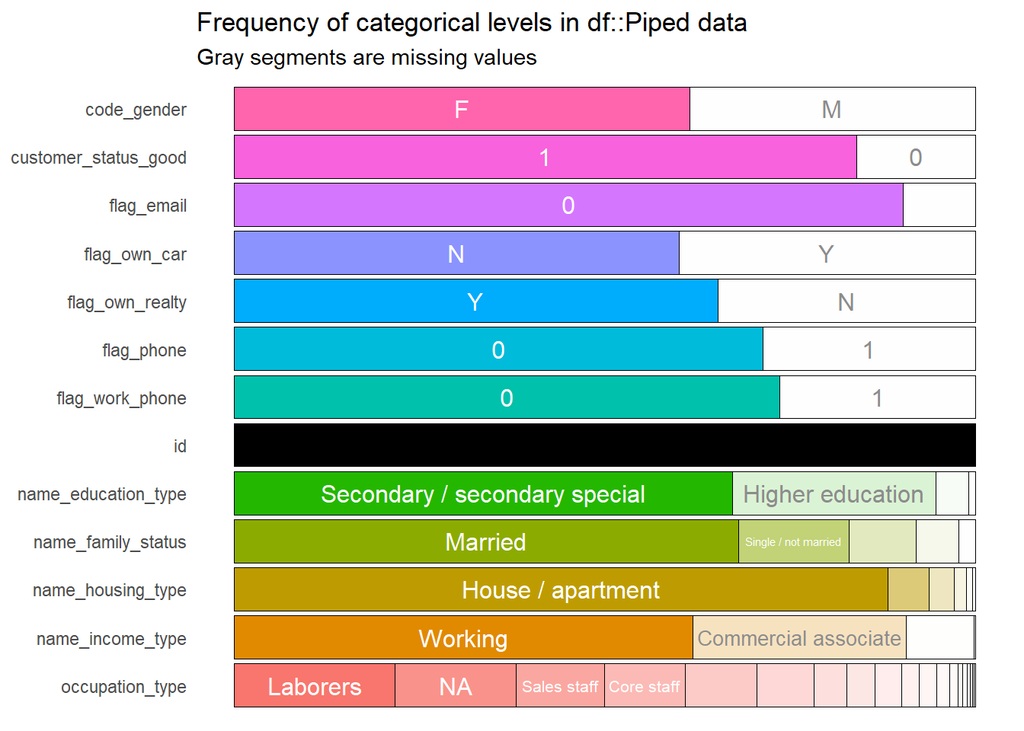

```r
df.cc %>%
  inspect_cat() %>%
  show_plot()
```

## Graphical Analysis

We would expect amt_income_total to have the strongest impact on percent_good or customer_status_good, respectively creditworthiness. We are also interested in seeing if variables such as code_gender, work_years, age_years, and name_education_type have a significant impact on the target variables.

### Overview of all the different variables

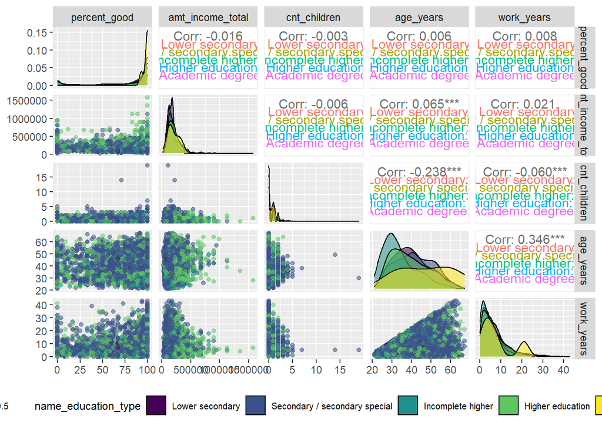

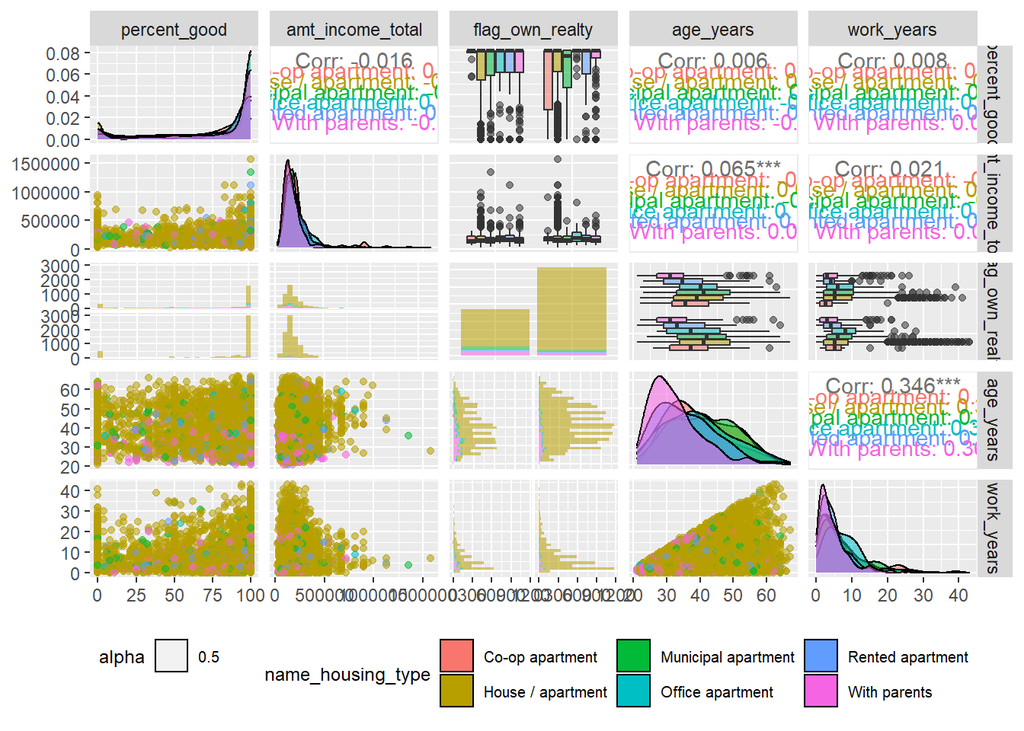

### GLM Poisson

For our GLM Poisson model we created the data frame “df.poisson” to get count data out of the original raw data as dependent variable. Therefore we have a closer look to the different status in the data set during the period of 24 months. The target variable in this model is status_count for the status X, C, 0, 1, 2, 3, 4, 5. For performance reasons, i.e. model creation takes very long with the whole data set, the data set is reduced by half using the caret function “createDataPartitioning”.

#### Data Set for Poisson

```r
head(df.poisson) %>% kable()
```

| status_count | code_gender | age_years | name_education_type | name_income_type | name_housing_type | name_family_status | cnt_children | cnt_fam_members | flag_own_car | flag_own_realty | work_years | amt_income_total | occupation_type | flag_work_phone | flag_phone | flag_email | status | months_balance |
| --- | --- | --- | --- | --- | --- | --- | --- | --- | --- | --- | --- | --- | --- | --- | --- | --- | --- | --- |
| 1 | F | 21 | Secondary / secondary special | Commercial associate | With parents | Single / not married | 0 | 1 | N | N | 2 | 90000 | Sales staff | 0 | 0 | 0 | 0 | -19 |
| 1 | F | 21 | Secondary / secondary special | Commercial associate | With parents | Single / not married | 0 | 1 | N | N | 2 | 90000 | Sales staff | 0 | 0 | 0 | 0 | -16 |
| 1 | F | 21 | Secondary / secondary special | Commercial associate | With parents | Single / not married | 0 | 1 | N | N | 2 | 90000 | Sales staff | 0 | 0 | 0 | 0 | -15 |
| 2 | F | 21 | Secondary / secondary special | Commercial associate | With parents | Single / not married | 0 | 1 | N | N | 2 | 90000 | Sales staff | 0 | 0 | 0 | 0 | -10 |
| 1 | F | 21 | Secondary / secondary special | Commercial associate | With parents | Single / not married | 0 | 1 | N | N | 2 | 90000 | Sales staff | 0 | 0 | 0 | C | -13 |
| 1 | F | 21 | Secondary / secondary special | Commercial associate | With parents | Single / not married | 0 | 1 | N | N | 2 | 90000 | Sales staff | 0 | 0 | 0 | C | -9 |

#### Data Visualization for Poisson

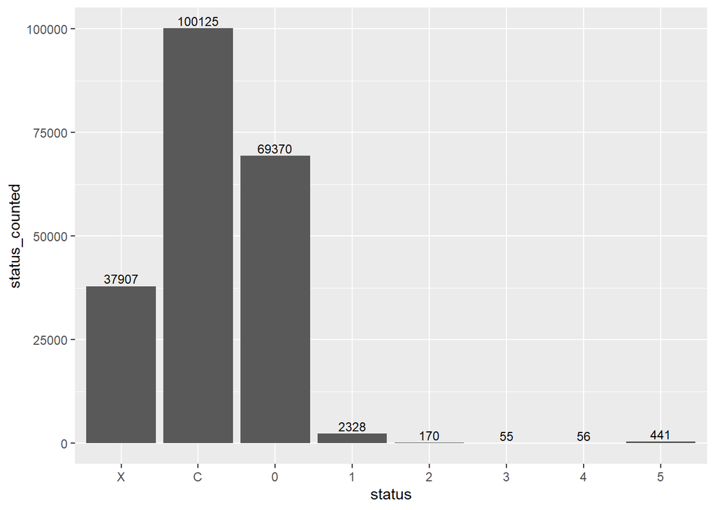

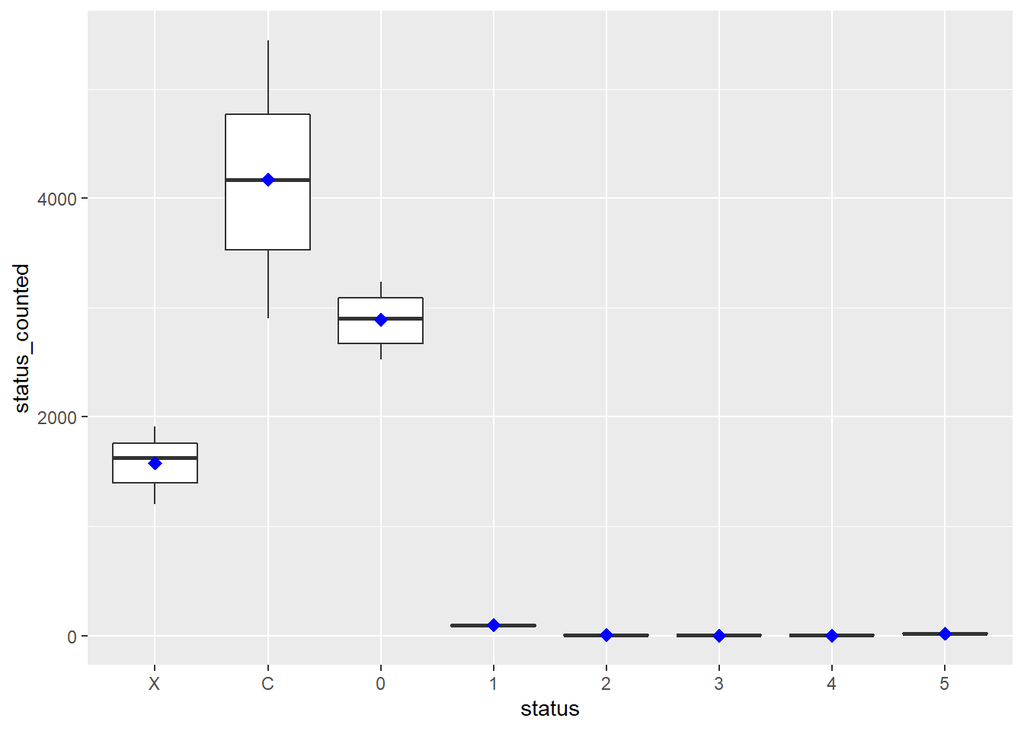

In the boxplot we can observe that the variability of count_status, i.e. count per status in the period of 24 months, increases with the mean value of every status. This behavior is typical for count data and therefore poisson models are suitable to analyze them.

```r
glm.1 <- glm(status_count ~ status,
             family = "poisson",
             data = df.poisson)
summary(glm.1)
```

```
##
## Call:
## glm(formula = status_count ~ status, family = "poisson", data = df.poisson)
##
## Deviance Residuals:
##     Min       1Q   Median       3Q      Max
## -0.8418  -0.5344  -0.5119   0.2769   9.3958
##
## Coefficients:
##              Estimate Std. Error z value Pr(>|z|)
## (Intercept)  0.471730   0.005136  91.845  < 2e-16 ***
## statusC      0.266785   0.006031  44.239  < 2e-16 ***
## status0      0.018997   0.006387   2.974 0.002937 **
## status1     -0.388928   0.021353 -18.215  < 2e-16 ***
## status2     -0.441877   0.076868  -5.749 9.00e-09 ***
## status3     -0.434689   0.134938  -3.221 0.001276 **
## status4     -0.453712   0.133729  -3.393 0.000692 ***
## status5     -0.322857   0.047895  -6.741 1.57e-11 ***
## ---
## Signif. codes:  0 '***' 0.001 '**' 0.01 '*' 0.05 '.' 0.1 ' ' 1
##
## (Dispersion parameter for poisson family taken to be 1)
##
##     Null deviance: 86964  on 116755  degrees of freedom
## Residual deviance: 82681  on 116748  degrees of freedom
## AIC: 359294
##
## Number of Fisher Scoring iterations: 5
```

```r
glm.2 <- update(glm.1, . ~ . * amt_income_total)
summary(glm.2)
```

```
##
## Call:
## glm(formula = status_count ~ status + amt_income_total + status:amt_income_total,
##     family = "poisson", data = df.poisson)
##
## Deviance Residuals:
##     Min       1Q   Median       3Q      Max
## -1.4422  -0.5736  -0.4905   0.3001   9.3093
##
## Coefficients:
##                            Estimate Std. Error z value Pr(>|z|)
## (Intercept)               3.976e-01  1.065e-02  37.342  < 2e-16 ***
## statusC                   2.820e-01  1.257e-02  22.439  < 2e-16 ***
## status0                   2.466e-02  1.315e-02   1.875   0.0608 .
## status1                  -3.031e-01  4.080e-02  -7.430 1.09e-13 ***
## status2                  -3.528e-01  1.771e-01  -1.992   0.0464 *
## status3                  -3.514e-01  2.605e-01  -1.349   0.1773
## status4                  -3.660e-01  2.737e-01  -1.337   0.1812
## status5                  -2.098e-01  9.859e-02  -2.127   0.0334 *
## amt_income_total          3.730e-07  4.643e-08   8.033 9.47e-16 ***
## statusC:amt_income_total -6.509e-08  5.552e-08  -1.172   0.2411
## status0:amt_income_total -2.663e-08  5.734e-08  -0.464   0.6424
## status1:amt_income_total -4.304e-07  1.712e-07  -2.514   0.0119 *
## status2:amt_income_total -4.514e-07  8.394e-07  -0.538   0.5907
## status3:amt_income_total -4.161e-07  1.049e-06  -0.397   0.6915
## status4:amt_income_total -4.372e-07  1.127e-06  -0.388   0.6982
## status5:amt_income_total -5.578e-07  4.111e-07  -1.357   0.1748
## ---
## Signif. codes:  0 '***' 0.001 '**' 0.01 '*' 0.05 '.' 0.1 ' ' 1
##
## (Dispersion parameter for poisson family taken to be 1)
##
##     Null deviance: 86964  on 116755  degrees of freedom
## Residual deviance: 82416  on 116740  degrees of freedom
## AIC: 359046
##
## Number of Fisher Scoring iterations: 5
```

```r
glm.3 <- glm(status_count ~ status * (amt_income_total + code_gender + age_years + name_education_type + name_income_type + name_housing_type + name_family_status + cnt_children + cnt_fam_members + flag_own_car + flag_own_realty + work_years + occupation_type),
             family = "poisson",
             data = df.poisson)
summary(glm.3)
```

```
##
## Call:
## glm(formula = status_count ~ status * (amt_income_total + code_gender +
##     age_years + name_education_type + name_income_type + name_housing_type +
##     name_family_status + cnt_children + cnt_fam_members + flag_own_car +
##     flag_own_realty + work_years + occupation_type), family = "poisson",
##     data = df.poisson)
##
## Deviance Residuals:
##     Min       1Q   Median       3Q      Max
## -2.0740  -0.6033  -0.4446   0.2954   9.0745
##
## Coefficients: (39 not defined because of singularities)
##                                                            Estimate Std. Error
## (Intercept)                                               8.466e-01  3.067e-01
## statusC                                                   5.098e-01  3.297e-01
## status0                                                  -6.811e-01  3.649e-01
## status1                                                  -3.321e-01  7.959e-01
## status2                                                  -4.879e-01  1.332e+00
## status3                                                  -2.392e-01  3.586e+00
## status4                                                   3.043e-01  4.547e+00
## status5                                                   8.991e-01  1.732e+00
## amt_income_total                                          4.973e-07  5.172e-08
## code_genderM                                             -7.597e-03  1.334e-02
## age_years                                                -2.907e-03  6.561e-04
## name_education_typeHigher education                      -3.448e-01  1.968e-01
## name_education_typeIncomplete higher                     -4.314e-01  1.981e-01
## name_education_typeLower secondary                       -3.053e-01  2.063e-01
## name_education_typeSecondary / secondary special         -3.501e-01  1.967e-01
## name_income_typePensioner                                -3.476e-01  1.010e+00
## name_income_typeState servant                             4.077e-02  2.002e-02
## name_income_typeStudent                                   2.076e-01  2.588e-01
## name_income_typeWorking                                   4.281e-02  1.203e-02
## name_housing_typeHouse / apartment                       -3.163e-01  6.037e-02
## name_housing_typeMunicipal apartment                     -2.349e-01  6.624e-02
## name_housing_typeOffice apartment                        -8.647e-02  7.797e-02
## name_housing_typeRented apartment                        -1.598e-01  7.088e-02
## name_housing_typeWith parents                            -2.426e-01  6.423e-02
## name_family_statusMarried                                -2.829e-04  1.862e-02
## name_family_statusSeparated                               1.207e-01  1.158e-01
```

[output cut: 674 more lines]

```
## status1:occupation_typeWaiters/barmen staff                0.529 0.596867
## status2:occupation_typeWaiters/barmen staff                0.056 0.955029
## status3:occupation_typeWaiters/barmen staff                   NA       NA
## status4:occupation_typeWaiters/barmen staff                   NA       NA
## status5:occupation_typeWaiters/barmen staff               -0.942 0.346067
## ---
## Signif. codes:  0 '***' 0.001 '**' 0.01 '*' 0.05 '.' 0.1 ' ' 1
##
## (Dispersion parameter for poisson family taken to be 1)
##
##     Null deviance: 86964  on 116755  degrees of freedom
## Residual deviance: 80408  on 116443  degrees of freedom
## AIC: 357632
##
## Number of Fisher Scoring iterations: 5
```

```r
formula(glm.2)
```

```
## status_count ~ status + amt_income_total + status:amt_income_total
```

```r
formula(glm.3)
```

```
## status_count ~ status * (amt_income_total + code_gender + age_years +
##     name_education_type + name_income_type + name_housing_type +
##     name_family_status + cnt_children + cnt_fam_members + flag_own_car +
##     flag_own_realty + work_years + occupation_type)
```

No overdispersion could be detected in models 1 to 3, for this reason we stay with the Poisson model and do not change to quasipoisson.

#### Check for most Important Variables in the GLM Poisson

With the varImp function from the package caret, we now examine which predictors are the most important in our GLM Poisson model. We investigate the variable importance in our most complex model glm.3.

```r
imp <- as.data.frame(varImp(glm.3))
imp <- data.frame(names   = rownames(imp),
                  overall = imp$Overall)
imp[order(imp$overall,decreasing = TRUE),]
```

```
##                                                        names     overall
## 8                                           amt_income_total 9.613929226
## 43                                   occupation_typeManagers 7.809821082
## 58                                      statusC:code_genderM 7.055227409
## 66                                         status0:age_years 6.237712859
## 49                             occupation_typeSecurity staff 5.820709105
## 272                          status0:occupation_typeManagers 5.319449760
## 19                        name_housing_typeHouse / apartment 5.240114987
## 190                                    statusC:flag_own_carY 5.102799016
## 10                                                 age_years 4.430800265
## 229                        status0:occupation_typeCore staff 4.335979322
## 120               status0:name_housing_typeHouse / apartment 4.152512590
## 37                                    occupation_typeDrivers 3.985327806
## 65                                         statusC:age_years 3.971688191
## 278                    statusC:occupation_typeMedicine staff 3.820806823
```

[output cut: 298 more lines]

#### Poisson model with most Importantant Variables

```r
glm.4 <- glm(status_count ~ amt_income_total + status:age_years + status:code_gender + occupation_type + status:work_years,
             family = "poisson",
             data = df.poisson)
summary(glm.4)
```

```
##
## Call:
## glm(formula = status_count ~ amt_income_total + status:age_years +
##     status:code_gender + occupation_type + status:work_years,
##     family = "poisson", data = df.poisson)
##
## Deviance Residuals:
##     Min       1Q   Median       3Q      Max
## -1.5376  -0.6110  -0.4667   0.2866   9.2350
##
## Coefficients:
##                                        Estimate Std. Error z value Pr(>|z|)
## (Intercept)                           5.613e-01  1.171e-02  47.923  < 2e-16 ***
## amt_income_total                      3.912e-07  2.163e-08  18.089  < 2e-16 ***
## occupation_typeAccountants            8.719e-03  1.194e-02   0.730 0.465384
## occupation_typeCleaning staff        -5.824e-02  1.713e-02  -3.400 0.000673 ***
## occupation_typeCooking staff         -8.229e-02  1.613e-02  -5.102 3.37e-07 ***
## occupation_typeCore staff            -1.625e-02  8.281e-03  -1.962 0.049780 *
## occupation_typeDrivers               -8.117e-02  1.020e-02  -7.954 1.81e-15 ***
## occupation_typeHR staff              -2.139e-01  4.467e-02  -4.790 1.67e-06 ***
## occupation_typeHigh skill tech staff -4.488e-03  1.124e-02  -0.399 0.689600
## occupation_typeIT staff              -1.182e-01  4.807e-02  -2.459 0.013927 *
## occupation_typeLaborers              -5.117e-02  7.266e-03  -7.042 1.89e-12 ***
## occupation_typeLow-skill Laborers    -5.680e-02  3.031e-02  -1.874 0.060953 .
## occupation_typeManagers              -7.277e-02  8.861e-03  -8.212  < 2e-16 ***
## occupation_typeMedicine staff        -2.705e-03  1.220e-02  -0.222 0.824475
## occupation_typePrivate service staff -3.513e-02  2.199e-02  -1.598 0.110085
## occupation_typeRealty agents          5.778e-02  5.133e-02   1.126 0.260373
## occupation_typeSales staff           -5.127e-02  8.526e-03  -6.013 1.82e-09 ***
## occupation_typeSecretaries           -1.315e-01  3.049e-02  -4.314 1.60e-05 ***
## occupation_typeSecurity staff        -1.228e-01  1.673e-02  -7.340 2.14e-13 ***
## occupation_typeWaiters/barmen staff  -1.121e-01  3.311e-02  -3.386 0.000708 ***
## statusX:age_years                    -3.678e-03  3.243e-04 -11.343  < 2e-16 ***
## statusC:age_years                     2.699e-03  2.645e-04  10.204  < 2e-16 ***
## status0:age_years                    -2.079e-03  2.838e-04  -7.327 2.36e-13 ***
## status1:age_years                    -1.278e-02  9.828e-04 -13.001  < 2e-16 ***
## status2:age_years                    -1.330e-02  3.254e-03  -4.089 4.34e-05 ***
## status3:age_years                    -1.379e-02  5.724e-03  -2.410 0.015959 *
## status4:age_years                    -1.455e-02  5.705e-03  -2.550 0.010758 *
## status5:age_years                    -7.746e-03  2.166e-03  -3.577 0.000348 ***
```

[output cut: 11 more lines]

```
## status1:work_years                    3.474e-03  3.557e-03   0.977 0.328760
## status2:work_years                    2.370e-03  1.264e-02   0.188 0.851260
## status3:work_years                    3.623e-03  2.243e-02   0.162 0.871659
## status4:work_years                    1.875e-03  2.383e-02   0.079 0.937258
## status5:work_years                   -1.611e-02  8.895e-03  -1.811 0.070103 .
## ---
## Signif. codes:  0 '***' 0.001 '**' 0.01 '*' 0.05 '.' 0.1 ' ' 1
##
## (Dispersion parameter for poisson family taken to be 1)
##
##     Null deviance: 86964  on 116755  degrees of freedom
## Residual deviance: 81796  on 116712  degrees of freedom
## AIC: 358481
##
## Number of Fisher Scoring iterations: 5
```

#### Performance Check of the GLM Poisson models

```
## # Comparison of Model Performance Indices
##
## Name  | Model | Nagelkerke's R2 |  RMSE | Sigma | Score_log | Score_spherical | AIC weights | BIC weights | Performance-Score
## -----------------------------------------------------------------------------------------------------------------------------
## glm.3 |   glm |           0.104 | 1.306 | 0.831 |    -1.529 |           0.003 |        1.00 |     < 0.001 |            71.43%
## glm.4 |   glm |           0.082 | 1.315 | 0.837 |    -1.535 |           0.003 |     < 0.001 |        1.00 |            46.12%
## glm.2 |   glm |           0.073 | 1.319 | 0.840 |    -1.537 |           0.003 |     < 0.001 |     < 0.001 |            18.56%
## glm.1 |   glm |           0.069 | 1.321 | 0.842 |    -1.539 |           0.003 |     < 0.001 |     < 0.001 |            14.29%
```

### GLM Binomial

Response variable: customer_status_good (good/bad customer)

```r
glm.bn1 <- glm(customer_status_good ~ amt_income_total,
                   family = "binomial",
                   data = df.cc)
summary(glm.bn1)
```

```
##
## Call:
## glm(formula = customer_status_good ~ amt_income_total, family = "binomial",
##     data = df.cc)
##
## Deviance Residuals:
##     Min       1Q   Median       3Q      Max
## -1.9391   0.5816   0.5878   0.5950   0.7567
##
## Coefficients:
##                    Estimate Std. Error z value Pr(>|z|)
## (Intercept)       1.727e+00  6.363e-02  27.144   <2e-16 ***
## amt_income_total -3.954e-07  2.906e-07  -1.361    0.174
## ---
## Signif. codes:  0 '***' 0.001 '**' 0.01 '*' 0.05 '.' 0.1 ' ' 1
##
## (Dispersion parameter for binomial family taken to be 1)
##
##     Null deviance: 6915.5  on 7838  degrees of freedom
## Residual deviance: 6913.7  on 7837  degrees of freedom
## AIC: 6917.7
##
## Number of Fisher Scoring iterations: 3
```